# Diagnostics and Influence Measures

## Residuals

Residual analysis and diagnostic methods are well developed for linear regression models (c.f., Cook and Weisberg, 1982), and they are somewhat less developed for mixed effects models.

This set of notes is based on [Nieuwenhuis et al](https://journal.r-project.org/archive/2012-2/RJournal_2012-2_Nieuwenhuis~et~al.pdf).

## Example: Orthodontics Data

We’ll consider the dental data with model

$$Y_{ij}=\beta_0+\beta_1I(\text{male})_i+\beta_2t_j+\beta_3I(\text{male})_it_j + b_{0i} + b_{1i}t_j + \varepsilon_{ij}$$

where

$$\begin{pmatrix} b_{0i} \\ b_{1i} \end{pmatrix} \overset{iid}\sim N\left(0,\begin{pmatrix}d_{11} & d_{12} \\ d_{12} & d_{22}\end{pmatrix}\right) \perp \varepsilon_{ij} \overset{iid}\sim N(0,\sigma^2)$$

for illustration.

## Residuals

*Residuals* $y_{ij}-\widehat{y}_{ij}$ can be helpful in flagging outliers and in assessing the adequacy of a fitted model. The definition of residuals is not always consistent in the case of mixed effects or hierarchical models:

- Many texts define residuals for subject/group $i$ as $Y_i-X_i\widehat{\beta}$
- Many software implementations define residuals as $Y_i-X_i\widehat{\beta}-Z_i\widehat{b}_i$ (nice because these can then be analyzed using standard methods)

We’ll run through the code to get some standard diagnostics (qq plot, RxP plot) as well as some visualizations that allow us to examine residuals by group/individual.

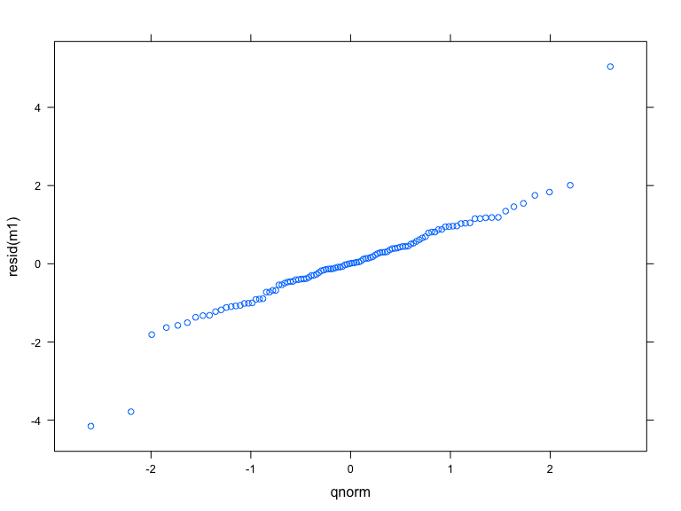

```r
library(lattice)
library(lme4)
data(Orthodont,package="nlme")
Orthodont$Sex=relevel(Orthodont$Sex,ref="Female")
m1=lmer(distance~Sex+age+age*Sex+(1+age|Subject),data=Orthodont)
#basic qqplot
qqmath(resid(m1))
```

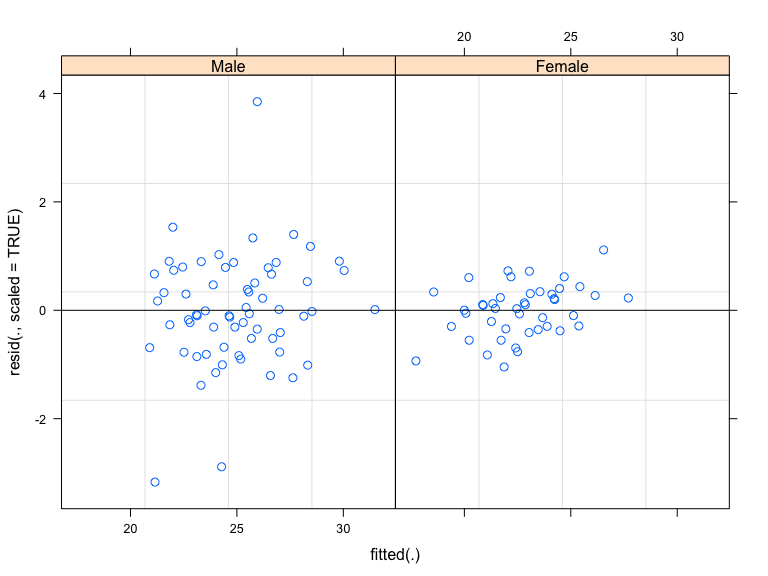

```r
#standardized residuals y-Xbeta-Zb versus fitted values by gender
#standardized by the estimate of sigma=sqrt(var(epsilon))
plot(m1,resid(.,scaled=TRUE)~fitted(.)|Sex,abline=0)
```

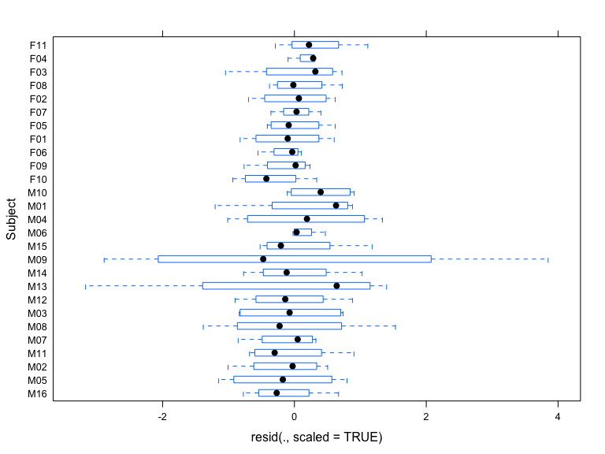

```r
## boxplots of residuals by Subject
plot(m1, Subject ~ resid(., scaled=TRUE))
```

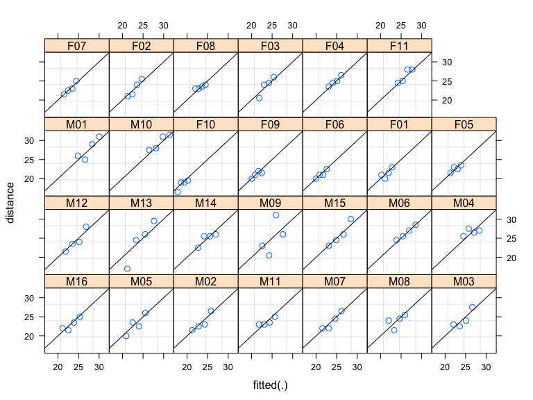

```r
## observed versus fitted values by Subject
## fitted value is X_ibeta+Z_ib_i
plot(m1, distance ~ fitted(.) | Subject, abline = c(0,1))
```

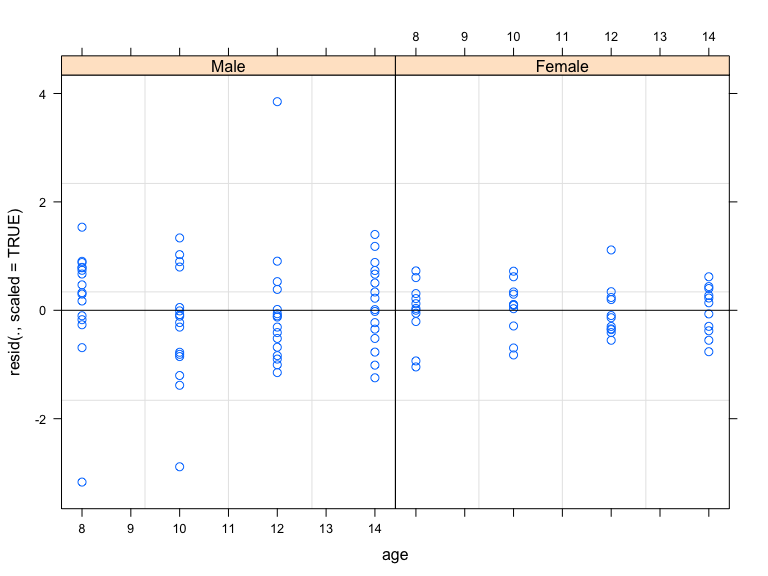

```r
## residuals by age, separated by Subject
plot(m1, resid(., scaled=TRUE) ~ age | Sex, abline = 0)
```

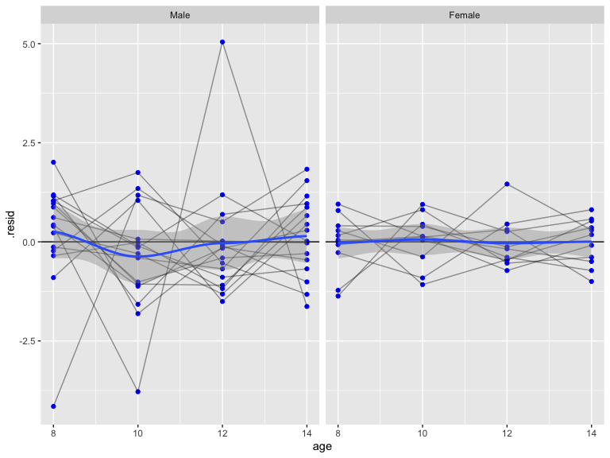

```r
library(ggplot2)
m1F <- fortify.merMod(m1)
# plot of raw residuals, use .scresid for scaled
ggplot(m1F, aes(age,.resid)) + geom_point(colour="blue") + facet_grid(.~Sex) +
        geom_hline(yintercept=0)+geom_line(aes(group=Subject),alpha=0.4)+geom_smooth(method="loess")
```

```r
## (warnings about loess are due to having only 4 unique x values)
```

Residual analysis is not always a great tool for detecting *influential* cases:

- Cases with high residuals or high standardized residuals are called *outliers*
- Outliers may or may not be influential in the model fit
- An influential case may dominate the regression model so that the line is drawn more closely towards the case (making it an *inlier*)

## Influence

We hope that all data points have some amount of influence on our parameter estimates. However, we may be concerned if a single case has disproportionate influence on model results. If so, one observation or group of observations may pull the estimated regression line towards the group. In such a case, excluding a single group might have a substantial effect on estimates. This idea is behind the development of many popular influence diagnostics, often termed *deletion* diagnostics.

## Leverage

The degree to which an observation has the *potential* to be influential is closely related to the *leverage* of the case, which is a measure of how extreme the case is in the $X$ space.

Leverage is not simply defined as an outlying value in $X$ space of a single variable but also in a multivariate sense. For example, in a study of pregnancy outcomes, it may be relatively common to have mothers who are 40, or fathers who are 20, but babies who have a 40 year old mother and a 20 year old father may be fairly uncommon.

It is not necessarily the case that outliers or cases with high leverage are influential. So, how do we detect influential cases?

One popular approach is to use the principle that when a single case is removed from the data entirely, we would like for models based on the data not to give vastly different conclusions.

If parameter estimates change a lot after a single individual is excluded, then the individual may be considered influential.

## Multi-Level Influence

Mixed effects and multilevel models estimate effects of lower-level and higher-level variables. It is thus possible that in some cases a higher-level group is influential (more likely when you don’t have very many groups), while in others, a single observation within a group is influential. We will examine influence at both levels.

## DFBETAS

*DFBETAS* measures the level of influence observations have on single parameter estimates. It is calculated as the difference in magnitude of the parameter estimate between the model including and the model excluding the group (or individual in a longitudinal study), standardized by dividing by the standard error of the estimate that excludes the group (to prevent variance inflation from masking the level of influence).

For group $i$ and parameter $k$,

$$\text{DFBETAS}_{ik}=\frac{\widehat{\gamma}_k-\widehat{\gamma}_{k(-i)}}{se(\widehat{\gamma}_{k(-i)})},$$
where $\widehat{\gamma}_k$ is the original estimate of the $k$th parameter, and $\widehat{\gamma}_{k(-i)}$ is the estimate of the same parameter after group $i$ has been excluded from the data.

```r
library(influence.ME)
m1.inf=influence(m1,"Subject")
print(2/sqrt(length(unique(Orthodont$Subject))))
dfbetas(m1.inf)
```

```
## [1] 0.3849002
```

```
##       (Intercept)    SexFemale           age SexFemale:age
## M16  3.792776e-02 -0.024669872 -1.743364e-01   0.113396005
## M05 -1.708339e-01  0.111117801  4.879626e-02  -0.031739214
## M02 -9.363421e-02  0.060903775 -6.935399e-03   0.004511086
## M11  2.345256e-01 -0.152545707 -3.514703e-01   0.228611641
## M07 -8.656237e-02  0.056303940  1.149669e-02  -0.007477952
## M08  2.173651e-01 -0.141383719 -3.133461e-01   0.203813988
## M03 -2.132601e-02  0.013871365 -2.542980e-02   0.016540653
## M12 -1.943286e-01  0.126399771  1.599342e-01  -0.104028181
## M13 -1.051725e+00  0.684087545  1.076023e+00  -0.699892393
## M14  1.736415e-01 -0.112943981 -1.936229e-01   0.125940795
## M09 -1.210886e-01  0.078761283  1.411130e-01  -0.091786074
## M15 -1.782330e-01  0.115930551  2.558523e-01  -0.166417501
## M06  1.630974e-01 -0.106085662 -8.046207e-02   0.052336042
## M04  5.799696e-01 -0.377237510 -4.866559e-01   0.316542214
## M01  5.964366e-02 -0.038794837  1.224129e-01  -0.079622675
## M10  3.147116e-01 -0.204702168 -2.528259e-02   0.016444898
## F10  1.676718e-12 -0.232617008 -1.424531e-12  -0.020879843
## F09  7.392377e-13  0.043449099 -7.500012e-13  -0.145739593
## F06  4.648603e-13 -0.022239646 -3.954377e-13  -0.074017034
## F01  5.813338e-13 -0.007326066 -4.996862e-13  -0.074064376
## F05  8.035070e-13  0.133505867 -8.771197e-13  -0.145456313
## F07  7.437522e-13 -0.025291926 -7.320104e-13   0.049929080
## F02  1.593488e-13 -0.191856576 -2.347268e-13   0.230866446
## F08  1.209541e-12  0.248809746 -1.071054e-12  -0.218999663
## F03  1.797969e-12 -0.179426730 -1.776067e-12   0.268665114
## F04  4.060678e-13  0.136799558 -2.972321e-13  -0.003211503
## F11  9.053009e-13  0.094416730 -8.116006e-13   0.139107896
```

Here we see that M04 and M13 are influential on some of our estimates. What did these kids look like?

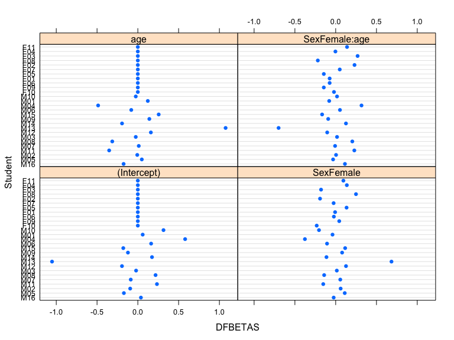

```r
plot(m1.inf,which="dfbetas",xlab="DFBETAS",ylab="Student")
```

```r
Orthodont$distance[Orthodont$Subject=="M04"]
```

```
## [1] 25.5 27.5 26.5 27.0
```

```r
Orthodont$distance[Orthodont$Subject=="M13"]
```

```
## [1] 17.0 24.5 26.0 29.5
```

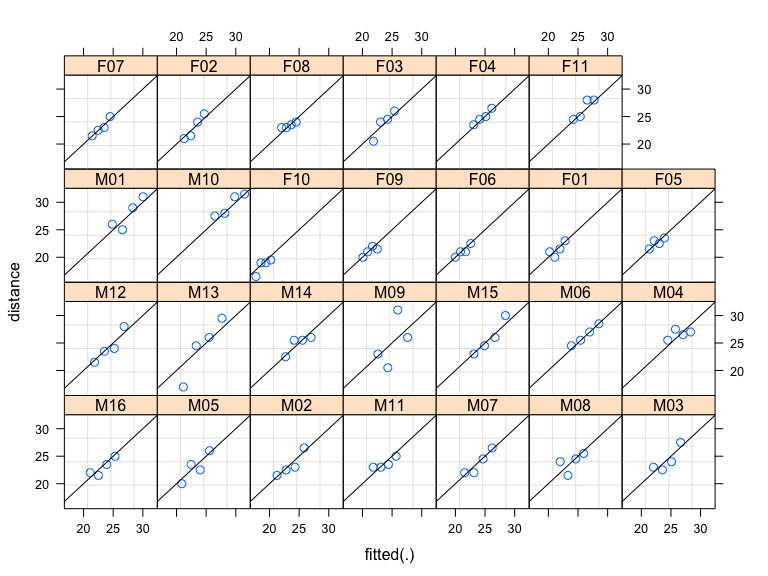

[output not shown]

[output not shown]

| ID | Int | Fem | Age | AbyF |
| --- | --- | --- | --- | --- |
| M04 | 0.58 | -0.38 | -0.49 | 0.32 |
| M13 | -1.05 | 0.68 | 1.08 | -0.70 |

```r
plot(m1, distance ~ fitted(.) | Subject, abline = c(0,1))
```

When the number of observations or predictors is large, it may take a while to wade through all the DFBETAS. *Cook’s distance* is a summary measure for influence on all parameter estimates. It is defined as

$$C_i=\frac{1}{p}(\widehat{\gamma}-\widehat{\gamma}_{(-i)})'\widehat{\Sigma}_{(-i)}^{-1}(\widehat{\gamma}-\widehat{\gamma}_{(-i)})$$

where $p$ is the length of $\beta$, and $\widehat{\Sigma}_{(-i)}$ is the covariance matrix of the parameter estimates excluding group $i$. Van der Meer et al (2010) recommends a cutoff of $\frac{4}{n}$ where again $n$ is the number of groups in the grouping factor being evaluated.

If there is just one parameter in the model, then Cook’s distance is the DFBETAS squared for that parameter.

```
## [1] 0.1481481
```

```
##            [,1]
## F07 0.001636431
## M03 0.002268299
## M09 0.004987715
## M07 0.006593856
## F05 0.008652563
## M14 0.009388496
## M12 0.009565544
## M06 0.011152793
## M02 0.011152818
## F01 0.011886446
## F06 0.016424229
## M15 0.018727159
## M05 0.018869728
## F02 0.021847932
## F09 0.022005758
## M16 0.023158496
## F08 0.025151739
## M08 0.027996778
## F04 0.033898436
## F03 0.035015308
## M11 0.036802012
## M01 0.038079939
## M04 0.084192285
## F11 0.110053787
## M10 0.116280355
## F10 0.137275861
## M13 0.312775049
```

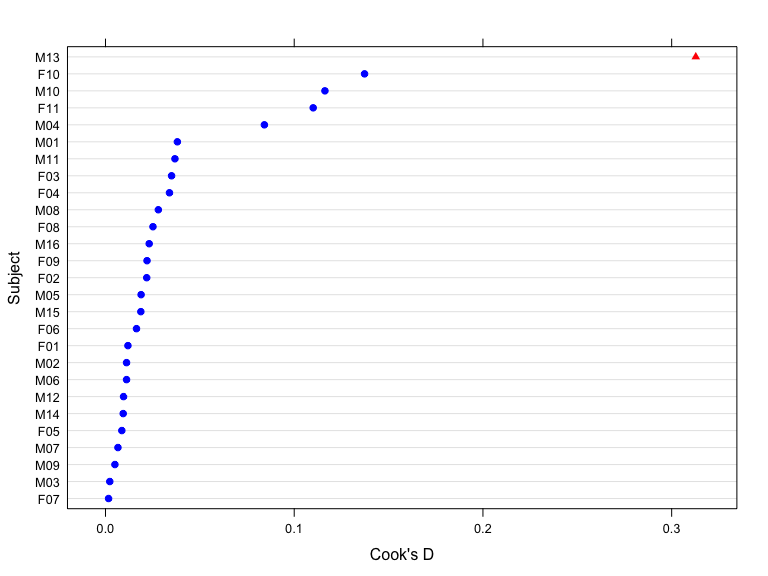

```r
print(4/length(unique(Orthodont$Subject)))
cooks.distance(m1.inf,sort=TRUE)
plot(m1.inf,which="cook",cutoff=4/length(unique(Orthodont$Subject)),
     sort=TRUE,xlab="Cook's D",ylab="Subject")
```

It’s M13 again.

Other metrics for evaluating influence include *percentile change* and *changes in significance*.

*Percentile change* is defined as
$$\frac{\widehat{\gamma}-\widehat{\gamma}_{(-i)}}{\widehat{\gamma}}\times 100%$$

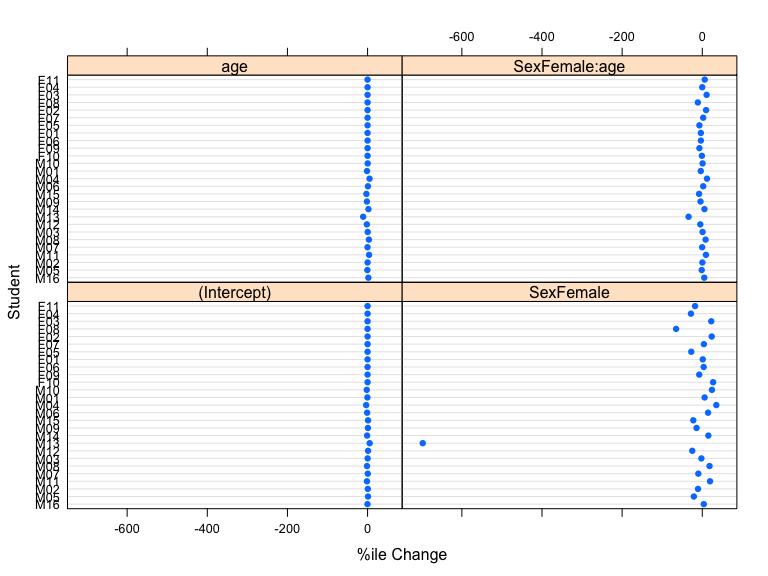

```r
plot(m1.inf,which="pchange",xlab="%ile Change",ylab="Student")
```

No surprise here!

Another metric is evaluating whether excluding a group changes the statistical significance of any of the estimates in the model. The user sets the critical value, and estimates that did not exceed it but do so when the group is removed, or *vice versa*, are flagged.

```r
#coding is a bit awkward here
sigtest(m1.inf,test=-2)
```

```
## $Intercept
##     Altered.Teststat Altered.Sig Changed.Sig
## M16         15.21779       FALSE       FALSE
## M05         15.73338       FALSE       FALSE
## M02         15.49028       FALSE       FALSE
## M11         15.26254       FALSE       FALSE
## M07         15.34391       FALSE       FALSE
## M08         15.40961       FALSE       FALSE
## M03         15.36725       FALSE       FALSE
## M12         15.60602       FALSE       FALSE
## M13         20.08981       FALSE       FALSE
## M14         15.25056       FALSE       FALSE
## M09         15.41510       FALSE       FALSE
## M15         15.55745       FALSE       FALSE
## M06         15.15731       FALSE       FALSE
## M04         16.42561       FALSE       FALSE
## M01         15.17863       FALSE       FALSE
## M10         15.39783       FALSE       FALSE
## F10         16.03332       FALSE       FALSE
## F09         15.74124       FALSE       FALSE
## F06         15.72143       FALSE       FALSE
## F01         15.72842       FALSE       FALSE
## F05         15.79364       FALSE       FALSE
## F07         15.76438       FALSE       FALSE
## F02         15.93306       FALSE       FALSE
## F08         16.07878       FALSE       FALSE
## F03         15.90331       FALSE       FALSE
## F04         15.82796       FALSE       FALSE
## F11         15.77239       FALSE       FALSE
##
## $SexFemale
##     Altered.Teststat Altered.Sig Changed.Sig
## M16        0.6514226       FALSE       FALSE
## M05        0.5282407       FALSE       FALSE
## M02        0.5716389       FALSE       FALSE
## M11        0.7892140       FALSE       FALSE
## M07        0.5705159       FALSE       FALSE
## M08        0.7833890       FALSE       FALSE
## M03        0.6165874       FALSE       FALSE
## M12        0.5067610       FALSE       FALSE
```

[output cut: 64 more lines]

```
## M06        -2.240254        TRUE       FALSE
## M04        -2.691716        TRUE       FALSE
## M01        -2.118537        TRUE       FALSE
## M10        -2.203888        TRUE       FALSE
## F10        -2.133358        TRUE       FALSE
## F09        -2.026185        TRUE       FALSE
## F06        -2.084143        TRUE       FALSE
## F01        -2.085476        TRUE       FALSE
## F05        -2.022247        TRUE       FALSE
## F07        -2.210167        TRUE       FALSE
## F02        -2.426963        TRUE       FALSE
## F08        -1.973040       FALSE        TRUE
## F03        -2.479383        TRUE       FALSE
## F04        -2.150502        TRUE       FALSE
## F11        -2.308625        TRUE       FALSE
```

```r
sigtest(m1.inf,test=2)
```

```
## $Intercept
##     Altered.Teststat Altered.Sig Changed.Sig
## M16         15.21779        TRUE       FALSE
## M05         15.73338        TRUE       FALSE
## M02         15.49028        TRUE       FALSE
## M11         15.26254        TRUE       FALSE
## M07         15.34391        TRUE       FALSE
## M08         15.40961        TRUE       FALSE
## M03         15.36725        TRUE       FALSE
## M12         15.60602        TRUE       FALSE
## M13         20.08981        TRUE       FALSE
## M14         15.25056        TRUE       FALSE
## M09         15.41510        TRUE       FALSE
## M15         15.55745        TRUE       FALSE
## M06         15.15731        TRUE       FALSE
## M04         16.42561        TRUE       FALSE
## M01         15.17863        TRUE       FALSE
## M10         15.39783        TRUE       FALSE
## F10         16.03332        TRUE       FALSE
## F09         15.74124        TRUE       FALSE
## F06         15.72143        TRUE       FALSE
## F01         15.72842        TRUE       FALSE
## F05         15.79364        TRUE       FALSE
## F07         15.76438        TRUE       FALSE
## F02         15.93306        TRUE       FALSE
## F08         16.07878        TRUE       FALSE
## F03         15.90331        TRUE       FALSE
## F04         15.82796        TRUE       FALSE
## F11         15.77239        TRUE       FALSE
##
## $SexFemale
##     Altered.Teststat Altered.Sig Changed.Sig
## M16        0.6514226       FALSE       FALSE
## M05        0.5282407       FALSE       FALSE
## M02        0.5716389       FALSE       FALSE
## M11        0.7892140       FALSE       FALSE
## M07        0.5705159       FALSE       FALSE
## M08        0.7833890       FALSE       FALSE
## M03        0.6165874       FALSE       FALSE
## M12        0.5067610       FALSE       FALSE
```

[output cut: 64 more lines]

```
## M06        -2.240254       FALSE       FALSE
## M04        -2.691716       FALSE       FALSE
## M01        -2.118537       FALSE       FALSE
## M10        -2.203888       FALSE       FALSE
## F10        -2.133358       FALSE       FALSE
## F09        -2.026185       FALSE       FALSE
## F06        -2.084143       FALSE       FALSE
## F01        -2.085476       FALSE       FALSE
## F05        -2.022247       FALSE       FALSE
## F07        -2.210167       FALSE       FALSE
## F02        -2.426963       FALSE       FALSE
## F08        -1.973040       FALSE       FALSE
## F03        -2.479383       FALSE       FALSE
## F04        -2.150502       FALSE       FALSE
## F11        -2.308625       FALSE       FALSE
```

## Influence of Lower-Level Observations

We can also look at the influence of single lower-level observations; they could be impactful in longitudinal data for example, when we have relatively few observations per individual. Note however that the computational complexity of these deletion diagnostics will be increased in this case.

Here we look at Cook’s Distance for the dental data on the individual observation level.

```r
m1.inf.indiv=influence(m1,obs=TRUE)
m1.cook=cooks.distance(m1.inf.indiv)
which(m1.cook>4/length(Orthodont$distance))
```

[output not shown]

[output cut: 94 more lines]

M13 once again!

## Dealing with Influential Data

What to do with influential data is a much harder problem. Reasonable strategies may include the following.

- Verify data recorded correctly
- Consider robust models
- Determine whether any lurking predictors should be added to the model
- Report results with and without overly influential results